# Final Project Part 2: Regression

# Model 6

For model 6, which was our second best model, the most important basic inputs appear to be x1 and x2, so we will use a larger sequence to represent those two inputs and just the median values for the others.

```r
expand_grid <- expand.grid(x1 = seq(min(df_derived$x1),max(df_derived$x1),length.out = 50),  #values between 0 and 1
                        x2 = seq(min(df_derived$x2),max(df_derived$x2),length.out = 9),
                        x3 = median(df_derived$x3),
                        x4 = median(df_derived$x4),
                        m = unique(df$m),
                        v1 = median(df_derived$v1),
                        v2 = median(df_derived$v2),
                        v3 = median(df_derived$v3),
                        v4 = median(df_derived$v4),
                        v5 = median(df_derived$v5),
                        output = 1,
                        w = median(df_derived$w),
                         z = median(df_derived$z),
                         t = median(df_derived$t),
                         x5 = median(df_derived$x5),
                        KEEP.OUT.ATTRS = FALSE,
                        stringsAsFactors = FALSE) %>%
  as.data.frame() %>% tibble::as_tibble()
```

Then we add the derived columns

```r
viz_grid <- expand_grid %>%
  #mutate(x5 = (1 - (x1 + x2 + x3 + x4))) %>%
  #mutate(w = x2 / (x3 + x4)) %>%
  #mutate(z = (x1 + x2) / (x4 + x5)) %>%
  #mutate(t = v1*v2) %>%
  mutate(binary = case_when(output < .33  ~ 'Event', output >=.33 ~ 'Non-Event'))
```

Now that we have this synthetic data, we can make predictions to view the trends produced by our linear model.

```r
mod6_predictions <- tidy_predict(lin_mod6, viz_grid)
```

Now with our predictions, we can visualize the predictive trends of the model.

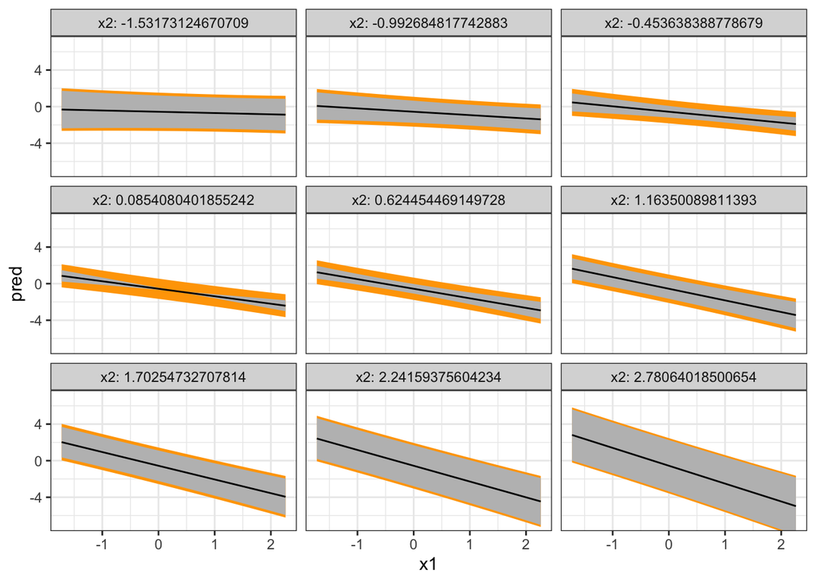

```r
mod6_predictions %>%
  ggplot(mapping = aes(x = x1)) +
  geom_ribbon(mapping = aes(ymin = pred_lwr, ymax = pred_upr),
              fill = 'orange') +
  geom_ribbon(mapping = aes(ymin = ci_lwr, ymax = ci_upr),
              fill = 'grey') +
  geom_line(mapping = aes(y = pred),
            color = 'black') +
  coord_cartesian(ylim = c(-7, 7)) +
  facet_wrap(~x2, labeller = "label_both") +
  theme_bw()
```

# Model 7

```r
expand_grid <- expand.grid(x1 = seq(min(df_derived$x1),max(df_derived$x1),length.out = 50),
                        x2 = seq(min(df_derived$x2),max(df_derived$x2),length.out = 9),
                        x3 = median(df_derived$x1),
                        x4 = median(df_derived$x4),
                        m = unique(df$m),
                        v1 = median(df_derived$v1),
                        v2 = median(df_derived$v2),
                        v3 = median(df_derived$v3),
                        v4 = median(df_derived$v4),
                        v5 = median(df_derived$v5),
                        output = 1,
                        w = median(df_derived$w),
                         z = median(df_derived$z),
                         t = median(df_derived$t),
                         x5 = median(df_derived$x5),
                        KEEP.OUT.ATTRS = FALSE,
                        stringsAsFactors = FALSE) %>%
  as.data.frame() %>% tibble::as_tibble()
```

Then we add the derived columns

```r
viz_grid <- expand_grid %>%
  #mutate(x5 = (1 - (x1 + x2 + x3 + x4))) %>%
  #mutate(w = x2 / (x3 + x4)) %>%
  #mutate(z = (x1 + x2) / (x4 + x5)) %>%
  #mutate(t = v1*v2) %>%
  mutate(binary = case_when(output < .33  ~ 'Event', output >=.33 ~ 'Non-Event'))
```

Now that we have this synthetic data, we can make predictions to view the trends produced by our linear model.

```r
mod7_predictions <- tidy_predict(lin_mod7, viz_grid)
```

Now with our predictions, we can visualize the predictive trends of the model.

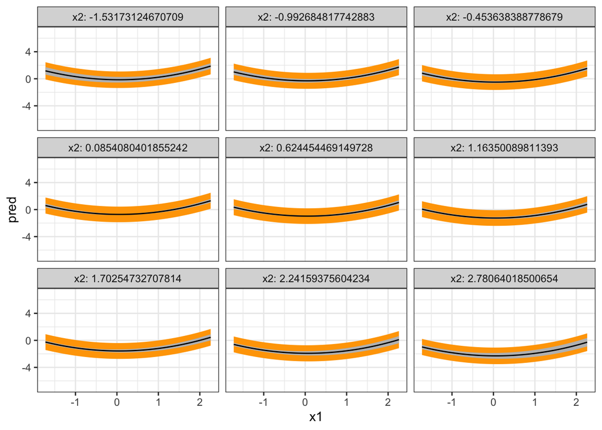

```r
mod7_predictions %>%
  ggplot(mapping = aes(x = x1)) +
  geom_ribbon(mapping = aes(ymin = pred_lwr, ymax = pred_upr),
              fill = 'orange') +
  geom_ribbon(mapping = aes(ymin = ci_lwr, ymax = ci_upr),
              fill = 'grey') +
  geom_line(mapping = aes(y = pred),
            color = 'black') +
  coord_cartesian(ylim = c(-7, 7)) +
  facet_wrap(~x2, labeller = "label_both") +
  theme_bw()
```

# Comparing the models

## Train and tune with resampling

To train and tune our models, I will use the carret package.

```r
library(caret)
```

We will use a resampling scheme with 5 folds and 5 repeats. Our primary performance metric will be RMSE

```r
my_ctrl <- trainControl(method = 'repeatedcv', number = 5, repeats = 5)

my_metric <- "RMSE"
```

# Linear Models

First we will tune four linear models.

Model 1: Additive features using the “base feature” set

```r
set.seed(15217)
caret_linear_mod1 <- train(transformed_output ~ x1 + x2 + x3 + x4 + v1 + v2 +v3 + v4 + v5,
                           data = df_derived,
                           method = 'lm',
                           metric = my_metric,
                            preProcess = c("center", "scale"),
                           trControl = my_ctrl)
```

Model 2: Additive features using the “expanded feature” set

```r
set.seed(15217)
caret_linear_mod2 <- train(transformed_output ~ x5 + t + z + w + v3 + v4 + v5,
                           data = df_derived,
                           method = 'lm',
                           metric = my_metric,
                            preProcess = c("center", "scale"),
                           trControl = my_ctrl)
```

Model 3: Model 6 from the previous section

```r
set.seed(15217)
caret_linear_mod3 <- train(transformed_output ~  (. - m - output - binary -x5) * (. - m - output - binary -x5) - v1:v2,
                           data = df_derived,
                           method = 'lm',
                           metric = my_metric,
                            preProcess = c("center", "scale"),
                           trControl = my_ctrl)
```

[output not shown]

[output cut: 19 more lines]

[output not shown]

Model 4: Model 7 from the previous section

```r
set.seed(15217)
caret_linear_mod4 <- train(transformed_output ~ . - m - output - binary -x5 + I(x1^2) + I(x2^2) + I(x3^2) + I(x4^2) + I(v1^2) + I(v2^2) + I(v3^2) + I(v4^2) + I(v5^2) + I(w^2) + I(z^2) + I(t^2),
                           data = df_derived,
                           method = 'lm',
                           metric = my_metric,
                            preProcess = c("center", "scale"),
                           trControl = my_ctrl)
```

# Regularized regression with Elastic net

Model 5: Interact the categorical variable with all pair-wise interactions of the continuous features

```r
#t and x5 are excluded, x5 because it is a simple combination of x1-4 and t because it is simply v1:v2 and included in the model regardless.
set.seed(15217)
caret_elastic_mod5 <- train(transformed_output ~  m * ( (x1 + x2 + x3 + x4 + v1 + v2 + v3 + v4 + v5 + z + w)*(x1 + x2 + x3 + x4 + v1 + v2 + v3 + v4 + v5 + z + w) ),
                           data = df_derived,
                           method = 'glmnet',
                           metric = my_metric,
                            preProcess = c("center", "scale"),
                           trControl = my_ctrl)
```

Model 6: Model 6 from the previous section

```r
set.seed(15217)
caret_elastic_mod6 <- train(transformed_output ~  (. - m - output - binary -x5) * (. - m - output - binary -x5) - v1:v2,
                           data = df_derived,
                           method = 'glmnet',
                           metric = my_metric,
                            preProcess = c("center", "scale"),
                           trControl = my_ctrl)
```

# Neural Network

Model 7: Base Features

```r
set.seed(15217)
caret_neural_mod7  <- train(transformed_output ~ x1 + x2 + x3 + x4 + v1 + v2 + v3 + v4 + v5 + m,
                           data = df_derived,
                           method = 'nnet',
                           metric = my_metric,
                            preProcess = c("center", "scale"),
                           trControl = my_ctrl,
                           trace = FALSE)
```

Model 8: Expanded Features

```r
set.seed(15217)
caret_neural_mod8  <- train(transformed_output ~ x5 + t + z + w + v3 + v4 + v5 + m,
                           data = df_derived,
                           method = 'nnet',
                           metric = my_metric,
                            preProcess = c("center", "scale"),
                           trControl = my_ctrl,
                           trace = FALSE)
```

# Random Forest

Model 9: Base Set

```r
set.seed(15217)
caret_forest_mod9 <- train(transformed_output ~ x1 + x2 + x3 + x4 + v1 + v2 + v3 + v4 + v5 + m,
                           data = df_derived,
                           method = 'rf',
                           metric = my_metric,
                           trControl = my_ctrl,
                           importance = TRUE)
```

Model 10: Expanded Features

```r
set.seed(15217)
caret_forest_mod10 <- train(transformed_output ~ x5 + t + z + w + v3 + v4 + v5 + m,
                           data = df_derived,
                           method = 'rf',
                           metric = my_metric,
                           trControl = my_ctrl,
                           importance = TRUE)
```

# Gradient Boosted Tree

Model 11: Base Features

```r
set.seed(15217)
caret_boosted_mod11 <- train(transformed_output ~ x1 + x2 + x3 + x4 + v1 + v2 + v3 + v4 + v5 + m,
                           data = df_derived,
                           method = 'xgbTree',
                           metric = my_metric,
                           trControl = my_ctrl,
                           verbosity = 0)
```

Model 12: Expanded Features

```r
set.seed(15217)
caret_boosted_mod12 <- train(transformed_output ~ x5 + t + z + w + v3 + v4 + v5 + m,
                           data = df_derived,
                           method = 'xgbTree',
                           metric = my_metric,
                           trControl = my_ctrl,
                           verbosity = 0)
```

# Two additional methods

Model 13: Partial Least Squares using the base features

```r
pls_grid <- expand.grid(ncomp = 1:5)
set.seed(15217)
caret_pls_mod13 <- train(transformed_output ~ x1 + x2 + x3 + x4 + v1 + v2 + v3 + v4 + v5 + m,
                 data = df_derived,
                 method = "pls",
                 metric = my_metric,
                 tuneGrid = pls_grid,
                 preProcess = c("center", "scale"),
                 trControl = my_ctrl)
```

Model 14:Support Vector Machines using the base features

```r
set.seed(15217)
caret_svm_mod14 <- train(transformed_output ~ x1 + x2 + x3 + x4 + v1 + v2 + v3 + v4 + v5 + m,
                 data = df_derived,
                 method = "svmRadial",
                 metric = my_metric,
                 preProcess = c("center", "scale"),
                 trControl = my_ctrl)
```

# Best Model

To help us select a best model, we will compare them using a dot plot.

```r
caret_compare <- resamples(list(Model_1 = caret_linear_mod1,
                                Model_2 = caret_linear_mod2,
                                Model_3 = caret_linear_mod3,
                                Model_4 = caret_linear_mod4,
                                Model_5 = caret_elastic_mod5,
                                Model_6 = caret_elastic_mod6,
                                Model_7 = caret_neural_mod7,
                                Model_8 = caret_neural_mod8,
                                Model_9 = caret_forest_mod9,
                                Model_10 = caret_forest_mod10,
                                Model_11 = caret_boosted_mod11,
                                Model_12 = caret_boosted_mod12,
                                Model_13 = caret_pls_mod13,
                                Model_14 = caret_svm_mod14
                                ))
```

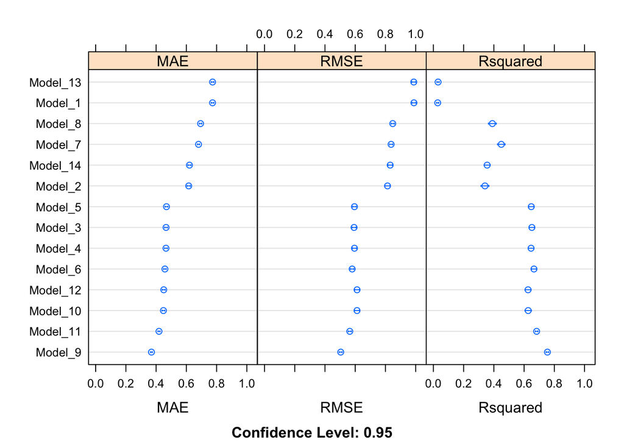

```r
dotplot(caret_compare)
```

Our training focused on minimizing the RMSE. Looking at model 9, we see that it has the lowest RMSE, and also both the highest R-Squared and the lowest MAE. It is pretty clear from this data that Model 9, the random forest model using the base data set, is the best model.